# Exercise 11

Keerthana Stanley

ANOVA Practice

loading in data:

```r
library(tidyverse)
f <- "https://raw.githubusercontent.com/difiore/ada-2024-datasets/main/AVONETdataset1.csv"

d <- read_csv(f, col_names = TRUE)
```

Winnow the dataset to include only the following variables: Species1, Family1, Order1, Beak.Length_Culmen, Beak.Width, Beak.Depth, Tarsus.Length, Wing.Length, Tail.Length, Mass, Habitat, Migration, Trophic.Level, Trophic.Niche, Min.Latitude, Max.Latitude, Centroid.Latitude, Primary.Lifestyle, ** and Range.Size

use select() to choose specific variables also using the pipe operator here

```r
d_winnowed <- d %>%
  select(Species1, Family1, Order1, Beak.Length_Culmen, Beak.Width, Beak.Depth, Tarsus.Length, Wing.Length, Tail.Length, Mass, Habitat, Migration, Trophic.Level, Trophic.Niche, Min.Latitude, Max.Latitude, Centroid.Latitude, Primary.Lifestyle, Range.Size)
```

Do a bit of exploratory data analysis with this dataset, e.g., using the {skimr} package.

QUESTION: Which of the variables are categorical and which are numeric?

categorical: Species1, Family1, Order1, Habitat, Trophic.Level, Trophic.Niche, Primary.Lifestyle

numeric: Beak.Length_Culmen, Beak.Width, Beak.Depth, Tarsus.Length, Wing.Length, Tail.Length, Mass, Migration, Min.Latitude, Max.Latitude, Centroid.Latitude, Range.Size

```r
library(skimr)

d_sumstats <- skim(d_winnowed)
```

CHALLENGE 1: One-Factor ANOVA

STEP 1–>

BOXPLOTS–> of log(Mass) in relation to Trophic.Level and Migration behavior type

For each plot, drop from the visualization all species records where the categorical variable of interest is missing from the dataset.

*** convert the variable Migration (which is scored as a number: “1”, “2”, or “3”) from class numeric to either being classified as a factor or as a character (string) variable!

CONVERTING MIGRATION TO BE CATEGORICAL can use the factor() function to do so: - categorical variables are represented as FACTORS, not strings!! - reference to Module 20 more documentation- https://www.rdocumentation.org/packages/base/versions/3.6.2/topics/factor

```r
d_winnowed$Migration <- factor(d_winnowed$Migration, levels = c("1", "2", "3"))

# re-running this to check
d_sumstats <- skim(d_winnowed)
```

now we can see that Migration is classified as a factor, not numeric

FILTERING DATA TO DROP MISSING DATA! using filter()

```r
d_filtered <- d_winnowed %>%
  filter(!is.na(Trophic.Level) & !is.na(Migration)) #drops missing values for Migration and Trophic Level
```

using !is.na to remove missing values: https://stackoverflow.com/questions/28857653/removing-na-observations-with-dplyrfilter

we already have Mass but we need log(Mass)

I’m using mutate() to add a new column for this!

```r
d_filtered <- d_filtered %>%
  mutate(log_Mass = log(Mass))
```

now time to make our boxplots– using ggplot2

also using geom_jitter() as shown in class- this function allows me to adjust (a.k.a ‘jitter’) points to prevent overplotting and clearly see the distributions of the data (need to adjust alpha value to make these points low opacity)

documentation- https://ggplot2.tidyverse.org/reference/geom_jitter.html#:~:text=The%20jitter%20geom%20is%20a,by%20discreteness%20in%20smaller%20datasets.

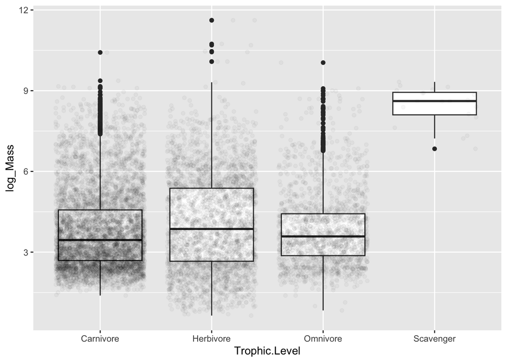

```r
library(ggplot2)

# where x=log(Mass) and y=Tropic Level
ggplot(data = d_filtered, aes(y = log_Mass, x = Trophic.Level)) + geom_boxplot() + geom_jitter(position = "jitter", alpha = 0.03)
```

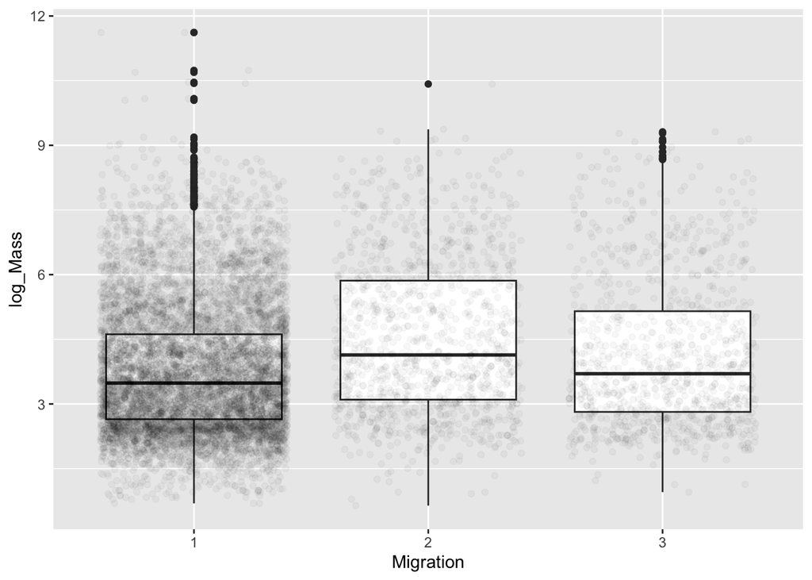

[output not shown]

```r
# where x=log(Mass) and y= Migration
ggplot(data = d_filtered, aes(y = log_Mass, x = Migration)) + geom_boxplot() + geom_jitter(position = "jitter", alpha = 0.03)
```

As shown in Modules 18 and 20, the lm() function is pretty simple to use here:

m1–> relation between log(Mass) and Tropic Level

```r
m1 <- lm(data = d_filtered, log_Mass ~ Trophic.Level)

summary(m1)
```

```
##
## Call:
## lm(formula = log_Mass ~ Trophic.Level, data = d_filtered)
##
## Residuals:
##     Min      1Q  Median      3Q     Max
## -3.4230 -1.1559 -0.3047  0.9004  7.5525
##
## Coefficients:
##                        Estimate Std. Error t value Pr(>|t|)
## (Intercept)             3.80916    0.01970 193.354  < 2e-16 ***
## Trophic.LevelHerbivore  0.25566    0.03410   7.498 6.96e-14 ***
## Trophic.LevelOmnivore   0.01410    0.04122   0.342    0.732
## Trophic.LevelScavenger  4.63107    0.34467  13.436  < 2e-16 ***
## ---
## Signif. codes:  0 '***' 0.001 '**' 0.01 '*' 0.05 '.' 0.1 ' ' 1
##
## Residual standard error: 1.539 on 10982 degrees of freedom
## Multiple R-squared:  0.02091,    Adjusted R-squared:  0.02064
## F-statistic: 78.18 on 3 and 10982 DF,  p-value: < 2.2e-16
```

```r
(critical_val_m1 <- qf(p = 0.95, df1 = 3, df2 = 10982))
```

```
## [1] 2.605718
```

```r
# where alpha = 0.05 and p = 1 - 0.05
```

m2–> relation between log(Mass) and Migration

```r
m2 <- lm(data = d_filtered, log_Mass ~ Migration)

summary(m2)
```

```
##
## Call:
## lm(formula = log_Mass ~ Migration, data = d_filtered)
##
## Residuals:
##     Min      1Q  Median      3Q     Max
## -3.8924 -1.1769 -0.3088  0.9152  7.8427
##
## Coefficients:
##             Estimate Std. Error t value Pr(>|t|)
## (Intercept)  3.77457    0.01636 230.710  < 2e-16 ***
## Migration2   0.75971    0.04731  16.059  < 2e-16 ***
## Migration3   0.37647    0.05155   7.303 3.02e-13 ***
## ---
## Signif. codes:  0 '***' 0.001 '**' 0.01 '*' 0.05 '.' 0.1 ' ' 1
##
## Residual standard error: 1.535 on 10983 degrees of freedom
## Multiple R-squared:  0.02563,    Adjusted R-squared:  0.02546
## F-statistic: 144.5 on 2 and 10983 DF,  p-value: < 2.2e-16
```

```r
(critical_val_m2 <- qf(p = 0.95, df1 = 2, df2 = 10983))
```

```
## [1] 2.99655
```

now let’s use relevel() function for Migration, as shown in Module 20

```r
d_filtered$Migration <- relevel(d_filtered$Migration, ref = "2") # assuming migratory type 2 to be baseline now
m2_relevel <- lm(log_Mass ~ Migration, data = d_filtered)
summary(m2_relevel)
```

```
##
## Call:
## lm(formula = log_Mass ~ Migration, data = d_filtered)
##
## Residuals:
##     Min      1Q  Median      3Q     Max
## -3.8924 -1.1769 -0.3088  0.9152  7.8427
##
## Coefficients:
##             Estimate Std. Error t value Pr(>|t|)
## (Intercept)  4.53428    0.04439 102.149  < 2e-16 ***
## Migration1  -0.75971    0.04731 -16.059  < 2e-16 ***
## Migration3  -0.38324    0.06603  -5.804 6.67e-09 ***
## ---
## Signif. codes:  0 '***' 0.001 '**' 0.01 '*' 0.05 '.' 0.1 ' ' 1
##
## Residual standard error: 1.535 on 10983 degrees of freedom
## Multiple R-squared:  0.02563,    Adjusted R-squared:  0.02546
## F-statistic: 144.5 on 2 and 10983 DF,  p-value: < 2.2e-16
```

[output not shown]

before I can compute permuted F-statistic values, I must compute the ACTUAL/original F-stat for log_Mass and Tropic.Level

r documentation shows that the calculate() function from {infer} workflow can compute the F-stat easily- https://www.rdocumentation.org/packages/infer/versions/1.0.5/topics/calculate

(similar use of the functions I will be using for permuted f stats)

```r
library(infer)

(original.F <- d_filtered %>%
  specify(log_Mass ~ Trophic.Level) %>%
  calculate(stat = "F"))
```

```
## Response: log_Mass (numeric)
## Explanatory: Trophic.Level (factor)
## # A tibble: 1 × 1
##    stat
##   <dbl>
## 1  78.2
```

now I can follow our methology from Module 16 (or more specific to this, Module 20.5) and generate a permutation test

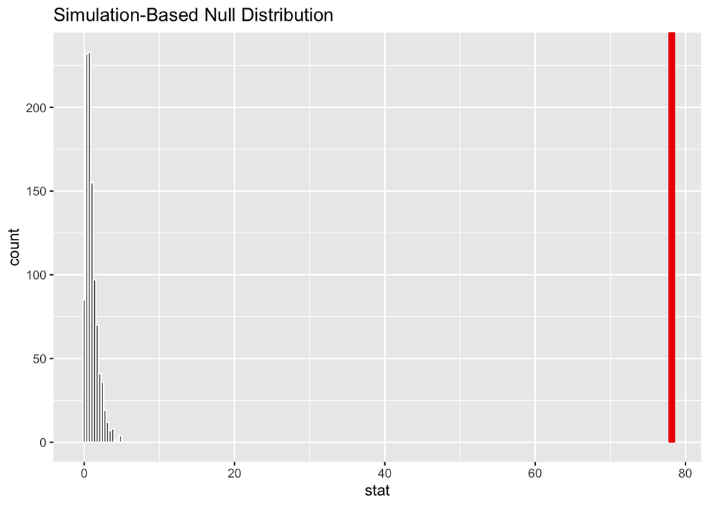

```r
permuted.F <- d_filtered %>%
  specify(log_Mass ~ Trophic.Level) %>%
  hypothesize(null = "independence") %>%
  generate(reps = 1000, type = "permute") %>%
  calculate(stat = "F")


# plot
visualize(permuted.F) +
  shade_p_value(obs_stat=original.F, direction="greater")
```

get p-value

```r
(p.value <- permuted.F %>%
  get_p_value(obs_stat = original.F, direction="greater"))
```

```
## # A tibble: 1 × 1
##   p_value
##     <dbl>
## 1       0
```

CHALLENGE 2:

STEP 1–>

Create the following two new variables and add them to AVONET dataset:

Relative beak length, which you should calculate as the residual of log(Beak.Length_Culmen) on log(Mass).

Relative tarsus length, which you should calculate as the residual of log(Tarsus.Length) on log(Mass).

first I’m geting the logs of the variables I need

```r
d_filtered <- d_filtered %>%
  mutate(log_Beak = log(Beak.Length_Culmen),
         log_Tarsus = log(Tarsus.Length)) %>%
  mutate(rel_Beak = residuals(lm(log_Beak ~ log_Mass, data = .)),
         rel_Tarsus = residuals(lm(log_Tarsus ~ log_Mass, data = .))) %>%
    filter(!is.na(rel_Tarsus) &
         !is.na(Primary.Lifestyle) &
         !is.na(rel_Beak) &
         !is.na(Trophic.Niche))
```

STEP 2–>

STEP 3 –>

Run ANOVA analyses to look at the association between geographic range size and the variable Migration.